# Every 15 minutes: Factors contributing to the illegal killing of African elephants

L Lathrop

2/12/2017

## Introduction

In the summer of 2012, more than 100 maurauders on horseback crossed from Chad into Cameroon’s Bouba Ndjidah National park with one mission: to kill as many elephants as possible without getting caught. Using rocket-propelled grenades and AK-47s, they mowed down hundreds of elephants, decimating entire herds, all for one reason: ivory.

The illegal killing of elephants in Africa for their ivory takes places sometimes on a small scale, with poisoned watermelons, and other times on a large scale, using belt-fed automatic weapons. But regardless of the method, when an elephant comes into contact with a poacher, more often than not, the poacher gets what he came for. This is why between 2010 and 2012 alone, some 100,000 elephants were slaughtered. Their only “crime” that they hold the ivory that the world cannot seem to resist.

### 1. Background

In 1979, some 1.3 million elephants roamed wild in the countries of Sub-Saharan Africa; a decade later, fewer than half that number remained. So in 1989, the Convention on Trade in Endangered Species of Wild Fauna and Flora (CITES) moved the elephant to its most restrictive Appendix and banned the international trade in ivory. Since then, CITES has allowed two large sales of stockpiled ivory, once in 1999 and again in 2008.

The sale in 1999 allowed three African nations—Zimbabwe, Botswana, and Namibia—to sell a portion of their stockpiles to Japan. At the time, however, no reliable ways of tracking the impact of poaching on illegal trade existed.

The second sale, in 2008, allowed the three countries from the 1999 sale, along with South Africa, to sell more than 100 tons of stockpiled ivory to Japan and China. By then, CITES had established a program to monitor illegal killing, so the impact of the sale on poaching could be evaluated.

From the start, however, the 2008 sale was problematic. In short, it was rigged. Japanese and Chinese buyers colluded to keep prices low, with each only bidding on certain types of ivory, e.g., full tusks vs. pieces. Thus, the invory fetched an average of just USD 67 per pound. But the Chince government then resold the ivory to its buyers for upwards of USD 500 per pound. Because of this, the price of ivory exploded and poaching became a much more lucrative activity.

The sale proved catastrophic for African elephant populations (Hsiang & Sekar, 2016). According to a report by the National Geographic Society, “the future of the African elephant may forever be clouded by the moment when CITES, lacking the data to evaluate the impact of its first ivory sale, endorsed a second” (Christy, 2012). Indeed, following the 2008 sale, the production of illegal ivory through poaching increased by 66% and ivory seizures from Africa increased by about 71% (Kelly, 2016). Current estimates of illegal killing are between 30,000 and 40,000 per year, or about one every 15 minutes.

### 2. Methods and Data

This project seeks to understand the socio-economic factors that may contribute to poaching. It is crucial for us to understand these contributing factors so that they may be remedied, thus allowing for the continuation of elephants in the wild. For it has been estimated that, at the current rate of killing, all elephants in the wild will be gone within 10 years.

Several researchers have studied the problem, and their findings will be taken into account in the model. For instance, Lemieux and Clark (2009) studied the effect of regulated and unregulated markets and showed that the presence of unregulated markets, either in-country or in a bordering country, had a significant impact on poaching activity.

The initial dataset included socio-economic and governance data on 34 countries with elephant populations in Central, Western, Eastern, and Southern Africa. These data came from the International Monetary Fund (IMF), the UN Development Programme (UNDP), the Unesco Institute for Statistics, The World Bank, and Transparency International (see the codebook for specifics). Information regarding regulated and unregulated ivory markets in Africa came from Lemieux and Clark (2009), and conflict data came from the Uppsala Conflict Data Programme (UCDP). Data concerning elephant populations and poaching came from the Monitoring the Illegal Killing of Elephants (MIKE) program of CITES.

Together, these data will allow a comprehensive assessment of one side of the poaching equation, namely, conditions in Africa that may contribute to illegal elephant killing. What these data do not address is the demand side of the equation. That is, we do not have the benefit of trafficking and sales data whereby illegal ivory is transmitted and sold to consumers, largely in Asian and Southeast Asian countries. Unfortunately such data is not readily accessible and gathering such data would be beyond the scope of this project.

The data were divided into training and test sets prior to imputation of missing values. Due to the limited number of observations relative to the number of variables, it was necessary to create a 60:40 split. Higher ratios of training set size to test set size were attempted, but imputation failed in those cases.

#### Figure 2.1.1: Correlation plot of variables

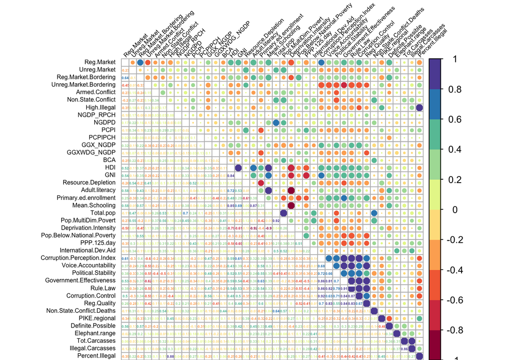

## 3. Exploratory data analysis

What’s more, when we examine mean scores for PIKE and several governance indicators, we see that Central Africa data show substantial problems for the region. The mean PIKE score, which represents the proportion of illegally killed elephants, for Central Africa is 0.68, substantially higher than any other region. And, for instance, the mean corruption control assessment for each region reveals Central Africa, at -1.1, to be substantially lower than Western, Southern, or Easterm Africa, which are -0.67, -0.19, -0.59, respectively.

#### Figure 3.1.1: Governance indicators for Central Africa

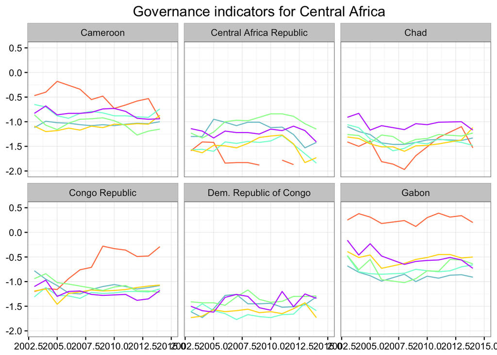

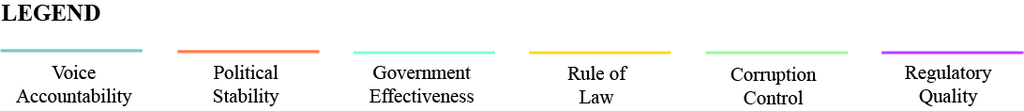

#### Figure 3.1.2: PIKE scores by region

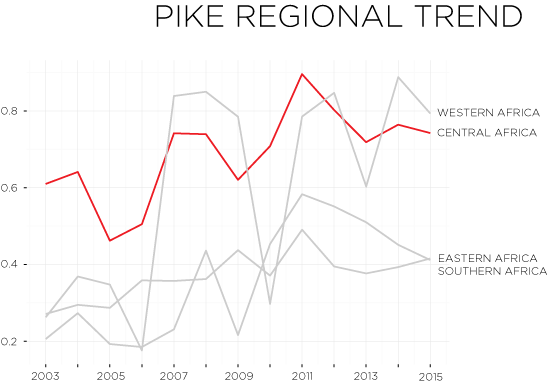

## 4. Data modeling and results

Multiple models were run in this analysis of the data, including pooled linear regression, model trees, gradient boosted machines (GBM), random forest, cubist, neural networks, and multivariate adaptive regression splines (MARS). Each of the aforementioned models have unique advantages, so it was thought that by running a number of them, a stable, robust result could be gleaned from the dataset.

#### 4.1 Pooled Linear Regression

Multiple regression using a pooled linear model from the `plm` package was run with `country` and `year` as index variables. Feature slection followed a forward selection procdure with = 0.10. The final model uses three variables that met the criteria. The variable `corruption control` had the lowest *p*-value, leading to an initial assumption that public corruption heavily influences the illegal killing of elephants. It should be noted that PLM was the only model to incorporate the longitudinal variables.

```r
# RUN POOLED LINEAR REGRESSION
eleph.train.plm <- plm(Percent.Illegal ~ Corruption.Control +
                                       PCPI + GGXWDG_NGDP,
                                     index=c("country", "year"),
                                    model = "between",
                                     data = outTrain)

rmsePLM <- sqrt(1-(0.54929 * sd(outTrain$Percent.Illegal)))
predPLM <- predict(eleph.train.plm, newdata = outTest)
measurePLM <- postResample(predPLM, outTest$Percent.Illegal)
summary(eleph.train.plm)
```

```
## Oneway (individual) effect Between Model
##
## Call:
## plm(formula = Percent.Illegal ~ Corruption.Control + PCPI + GGXWDG_NGDP,
##     data = outTrain, model = "between", index = c("country",
##         "year"))
##
## Unbalanced Panel: n=28, T=1-11, N=181
## Observations used in estimation: 28
##
## Residuals :
##    Min. 1st Qu.  Median 3rd Qu.    Max.
## -1.4900 -0.2860  0.0179  0.3070  0.9480
##
## Coefficients :
##                      Estimate Std. Error t-value Pr(>|t|)
## (Intercept)         0.0088681  0.1048578  0.0846 0.933303
## Corruption.Control -0.4016613  0.1138054 -3.5294 0.001713 **
## PCPI                0.1714095  0.1270903  1.3487 0.190016
## GGXWDG_NGDP         0.1422126  0.0830676  1.7120 0.099789 .
## ---
## Signif. codes:  0 '***' 0.001 '**' 0.01 '*' 0.05 '.' 0.1 ' ' 1
##
## Total Sum of Squares:    14.023
## Residual Sum of Squares: 7.2883
## R-Squared:      0.48026
## Adj. R-Squared: 0.41529
## F-statistic: 7.39223 on 3 and 24 DF, p-value: 0.0011286
```

```r
measurePLM
```

```
##      RMSE  Rsquared
## 0.8611339 0.2010074
```

#### 4.2 Model trees

```r
# RUN MODEL TREE ALGORITHM

registerDoMC(cores = 3)
m5train <- M5P(Percent.Illegal ~ ., data = outTrainSub)

set.seed(100)
measure1M5 <- postResample(m5train$predictions, outTrainSub$Percent.Illegal)
predM5 <- predict(m5train, newdata = outTestSub)
measureM5 <- postResample(predM5, outTestSub$Percent.Illegal)
summary(m5train)
```

```
##
## === Summary ===
##
## Correlation coefficient                  0.572
## Mean absolute error                      0.6854
## Root mean squared error                  0.8386
## Relative absolute error                 75.0898 %
## Root relative squared error             82.0286 %
## Total Number of Instances              181
```

```r
measureM5
```

```
##      RMSE  Rsquared
## 0.9482970 0.1682088
```

#### 4.3 GBM Trees

Gradient boosted machine models were run on the data, starting with 100 trees, and ultimately using 1000 trees. The model fitted to the training set achieved an $R^2$ of 0.423 and a cross-validated RMSE of 0.855. But $R^2$ fell to 0.229 when the model was applied to the test set, though RMSE held at 0.853.

```r
# RUN GBM TREE MODEL
set.seed(100)
modelGBM <- gbm(Percent.Illegal ~ ., data = outTrainSub,
                distribution = "gaussian",
                n.trees = 1000,
                n.minobsinnode = 2,
                cv.folds = 10,
                shrinkage = 0.001)
modelGBM
```

```
## gbm(formula = Percent.Illegal ~ ., distribution = "gaussian",
##     data = outTrainSub, n.trees = 1000, n.minobsinnode = 2, shrinkage = 0.001,
##     cv.folds = 10)
## A gradient boosted model with gaussian loss function.
## 1000 iterations were performed.
## The best cross-validation iteration was 1000.
## There were 31 predictors of which 25 had non-zero influence.
```

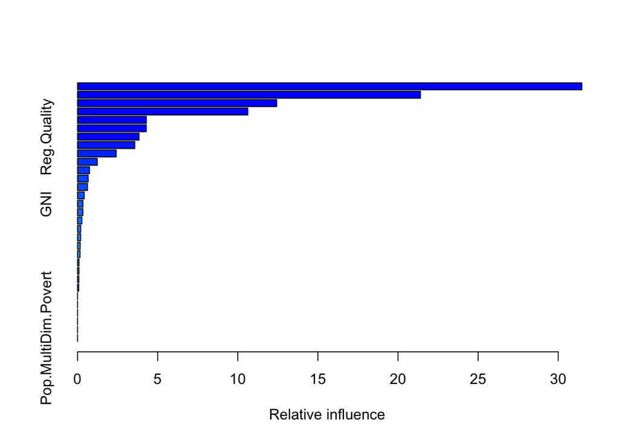

```
##                                                   var     rel.inf
## Corruption.Control                 Corruption.Control 31.47442044
## GGX_NGDP                                     GGX_NGDP 21.40167294
## Voice.Accountability             Voice.Accountability 12.42842798
## Political.Stability               Political.Stability 10.62722399
## Rule.Law                                     Rule.Law  4.29345688
## PCPI                                             PCPI  4.29075067
## Reg.Quality                               Reg.Quality  3.83501770
## Adult.literacy                         Adult.literacy  3.57123971
## Unreg.Market.Bordering         Unreg.Market.Bordering  2.41297325
## PPP.125.day                               PPP.125.day  1.23223799
## Resource.Depletion                 Resource.Depletion  0.74614047
## International.Dev.Aid           International.Dev.Aid  0.66383792
## Pop.Below.National.Poverty Pop.Below.National.Poverty  0.61833657
## NGDPD                                           NGDPD  0.41337751
## GNI                                               GNI  0.33628288
## Elephant.range                         Elephant.range  0.33193572
## NGDP_RPCH                                   NGDP_RPCH  0.27156658
## PCPIPCH                                       PCPIPCH  0.20011467
## Non.State.Conflict                 Non.State.Conflict  0.19550873
## Definite.Possible                   Definite.Possible  0.16561892
## BCA                                               BCA  0.15493844
## Reg.Market.Bordering             Reg.Market.Bordering  0.09031824
## Deprivation.Intensity           Deprivation.Intensity  0.08790488
## Reg.Market                                 Reg.Market  0.08253252
## Non.State.Conflict.Deaths   Non.State.Conflict.Deaths  0.07416441
## Unreg.Market                             Unreg.Market  0.00000000
## Armed.Conflict                         Armed.Conflict  0.00000000
## GGXWDG_NGDP                               GGXWDG_NGDP  0.00000000
## Primary.ed.enrollment           Primary.ed.enrollment  0.00000000
## Mean.Schooling                         Mean.Schooling  0.00000000
## Pop.MultiDim.Povert               Pop.MultiDim.Povert  0.00000000
```

```r
summary(modelGBM)
```

```r
measure1GBM <- postResample(modelGBM$fit, outTrainSub$Percent.Illegal)
predGBM <- predict.gbm(modelGBM, newdata = outTestSub,
                       n.trees = 1000)
measureGBM <- postResample(predGBM, outTestSub$Percent.Illegal)
```

#### 4.4 Random Forest

```r
# RUN RANDOM FOREST MODEL
set.seed(100)
fitControl <- trainControl(method = "cv", number = 10,
                           returnData = TRUE,
                           savePredictions = TRUE)

modelRF <- train(Percent.Illegal ~ ., data=outTrainSub,
                 method = "rf",
                 trControl=fitControl,
                 ntrees=1000,
                 allowParallel=TRUE,
                 prox=TRUE,
                 importance=TRUE)

predRF <- predict(modelRF, newdata = outTestSub)
measureRF <- postResample(predRF, outTestSub$Percent.Illegal)
modelRF
```

```
## Random Forest
##
## 181 samples
##  31 predictor
##
## No pre-processing
## Resampling: Cross-Validated (10 fold)
## Summary of sample sizes: 163, 162, 164, 162, 162, 162, ...
## Resampling results across tuning parameters:
##
##   mtry  RMSE       Rsquared
##    2    0.8187644  0.3801499
##   16    0.8406815  0.3484128
##   31    0.8498744  0.3363597
##
## RMSE was used to select the optimal model using  the smallest value.
## The final value used for the model was mtry = 2.
```

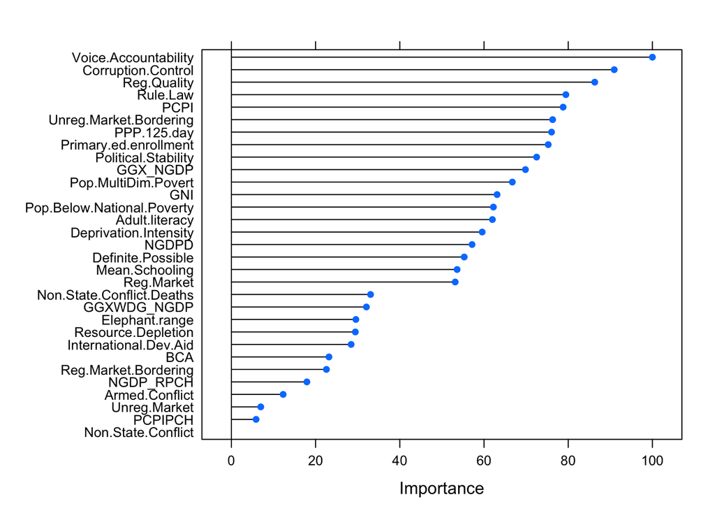

```r
plot(varImp(modelRF))
```

#### 4.5 Neural Networks

```r
# RUN NEURAL NETWORK MODEL
nnetGrid <- expand.grid(.decay = c(0, 0.01, 0.1),
                        .size = c(1:10),
                        .bag = FALSE)
set.seed(100)
modelNN <- train(Percent.Illegal ~ ., data = outTrainSub,
                 method = "avNNet",
                 tuneGrid = nnetGrid,
                 trControl = fitControl,
                 lineout = TRUE,
                 trace = FALSE,
                 MaxNWts = 10 + (ncol(outTrainSub) + 1) + 10 + 1,
                 maxit = 500,
                 importance=TRUE)

predNN <- predict(modelNN, newdata = outTestSub)
measureNN <- postResample(predNN, outTestSub$Percent.Illegal)
modelNN
```

```
## Model Averaged Neural Network
##
## 181 samples
##  31 predictor
##
## No pre-processing
## Resampling: Cross-Validated (10 fold)
## Summary of sample sizes: 163, 162, 164, 162, 162, 162, ...
## Resampling results across tuning parameters:
##
##   decay  size  RMSE      Rsquared
##   0.00    1    1.020506        NaN
##   0.00    2         NaN        NaN
##   0.00    3         NaN        NaN
##   0.00    4         NaN        NaN
##   0.00    5         NaN        NaN
##   0.00    6         NaN        NaN
##   0.00    7         NaN        NaN
##   0.00    8         NaN        NaN
##   0.00    9         NaN        NaN
##   0.00   10         NaN        NaN
##   0.01    1    1.013479  0.1384677
##   0.01    2         NaN        NaN
##   0.01    3         NaN        NaN
##   0.01    4         NaN        NaN
##   0.01    5         NaN        NaN
##   0.01    6         NaN        NaN
##   0.01    7         NaN        NaN
##   0.01    8         NaN        NaN
##   0.01    9         NaN        NaN
##   0.01   10         NaN        NaN
##   0.10    1    1.008022  0.1273255
##   0.10    2         NaN        NaN
##   0.10    3         NaN        NaN
##   0.10    4         NaN        NaN
##   0.10    5         NaN        NaN
##   0.10    6         NaN        NaN
##   0.10    7         NaN        NaN
##   0.10    8         NaN        NaN
##   0.10    9         NaN        NaN
##   0.10   10         NaN        NaN
##
## Tuning parameter 'bag' was held constant at a value of FALSE
## RMSE was used to select the optimal model using  the smallest value.
## The final values used for the model were size = 1, decay = 0.1 and bag
##  = FALSE.
```

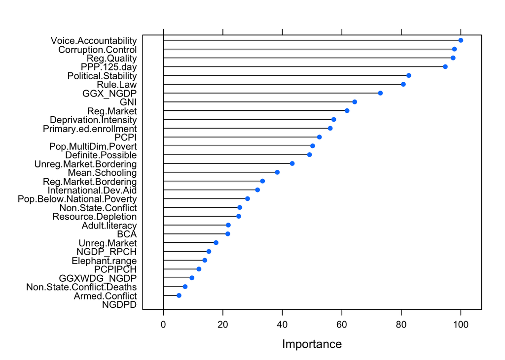

```r
plot(varImp(modelNN))
```

#### 4.6 Cubist

```r
# RUN CUBIST MODEL

modelCubist <- train(Percent.Illegal ~ ., data = outTrainSub,
                     method = "cubist",
                     trControl = fitControl,
                     importance = TRUE)

predCubist <- predict(modelCubist, newdata = outTestSub)
measureCubist <- postResample(predCubist, outTestSub$Percent.Illegal)
modelCubist
```

```
## Cubist
##
## 181 samples
##  31 predictor
##
## No pre-processing
## Resampling: Cross-Validated (10 fold)
## Summary of sample sizes: 162, 162, 163, 165, 164, 162, ...
## Resampling results across tuning parameters:
##
##   committees  neighbors  RMSE       Rsquared
##    1          0          0.9234211  0.2636218
##    1          5          0.8805619  0.3225872
##    1          9          0.8867753  0.3109280
##   10          0          0.8864990  0.2990874
##   10          5          0.8565508  0.3508454
##   10          9          0.8614355  0.3434626
##   20          0          0.8977398  0.2877349
##   20          5          0.8703808  0.3351470
##   20          9          0.8751072  0.3283268
##
## RMSE was used to select the optimal model using  the smallest value.
## The final values used for the model were committees = 10 and neighbors = 5.
```

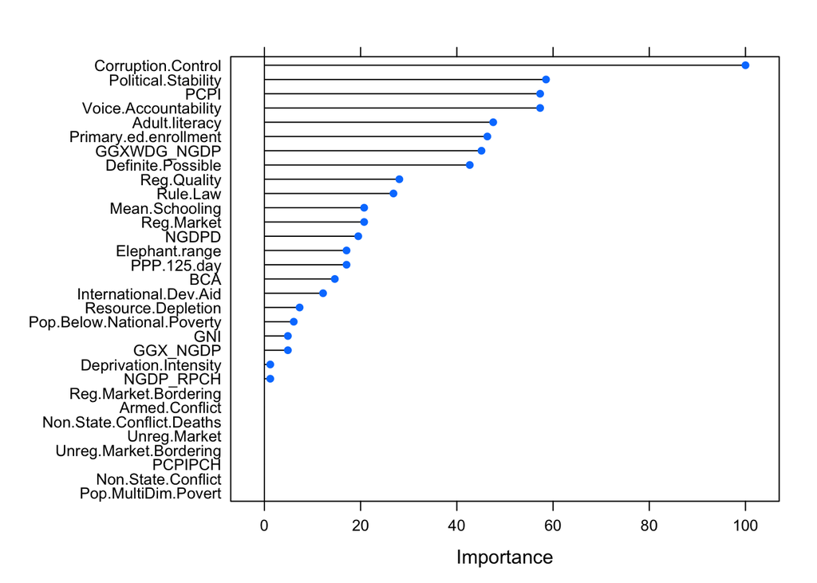

```r
plot(varImp(modelCubist))
```

#### 4.7 Multivariate Additive Regression Splines

```r
# RUN MARS MODEL
set.seed(100)
earthMars <- earth(Percent.Illegal ~ ., data = outTrainSub)

MarsRMSE <- sqrt(1 - (0.6888798 * sd(outTrainSub$Percent.Illegal)))
predMars <- predict(earthMars, newdata = outTestSub)
measureMars <- postResample(predMars, outTestSub$Percent.Illegal)
earthMars
```

```
## Selected 28 of 50 terms, and 11 of 31 predictors
## Termination condition: Reached nk 63
## Importance: PCPI, GNI, Adult.literacy, Pop.Below.National.Poverty, ...
## Number of terms at each degree of interaction: 1 27 (additive model)
## GCV 0.6012546    RSS 52.73767    GRSq 0.4310111    RSq 0.7211954
```

```r
evimp(earthMars)
```

```
##                            nsubsets   gcv    rss
## PCPI                             21 100.0  100.0
## GNI                              19  97.2   94.7
## Adult.literacy                   19  97.2   94.7
## Pop.Below.National.Poverty       19  97.2   94.7
## Non.State.Conflict.Deaths        19  97.2   94.7
## NGDP_RPCH                        17  77.4   82.5
## Primary.ed.enrollment            16  67.1   76.7
## Unreg.Market.Bordering           16  63.5>  78.6>
## NGDPD                            15  58.5   71.7
## GGXWDG_NGDP                      14  58.6   69.5
## Elephant.range                   10  40.6   54.9
## Corruption.Control-unused         7  89.5>  82.6>
## Reg.Quality-unused                7  87.1   82.1
```